# MA5

Joe Littell

November 12, 2018

# Methods and Analysis #4

### Question #1 pertains to a small dataset comparing a tree’s age to its diameter

In order to implement methods to replace missing data we first must remove data from the completed data set. In order to do so I removed 6 entries utlizing the sample() function which returns a vector of a set number in a specified range. That vector was then set inside the $age column to turn 6 entries into NA’s.

To ensure the proper number of data was removed I did a summary and md.pattern below.

```r
summary(trees)                           # initial look at the data
```

```
##      number         diameter           age
##  Min.   : 1.00   Min.   : 5.700   Min.   : 61.0
##  1st Qu.: 5.75   1st Qu.: 7.975   1st Qu.: 84.5
##  Median :10.50   Median : 9.250   Median :102.5
##  Mean   :10.50   Mean   : 9.405   Mean   :107.4
##  3rd Qu.:15.25   3rd Qu.:10.850   3rd Qu.:122.8
##  Max.   :20.00   Max.   :12.000   Max.   :168.0
```

```r
# Remove data
missingindex <- sample(1:20, 6)          # choose 6 numbers at random between 1-20
trees$age[missingindex] = NA             # Index at those six numbers and change the corresponding age to NA

summary(trees)                           # ensure that data was removed
```

```
##      number         diameter           age
##  Min.   : 1.00   Min.   : 5.700   Min.   : 61.00
##  1st Qu.: 5.75   1st Qu.: 7.975   1st Qu.: 85.75
##  Median :10.50   Median : 9.250   Median :102.50
##  Mean   :10.50   Mean   : 9.405   Mean   :109.71
##  3rd Qu.:15.25   3rd Qu.:10.850   3rd Qu.:131.00
##  Max.   :20.00   Max.   :12.000   Max.   :168.00
##                                   NA's   :6
```

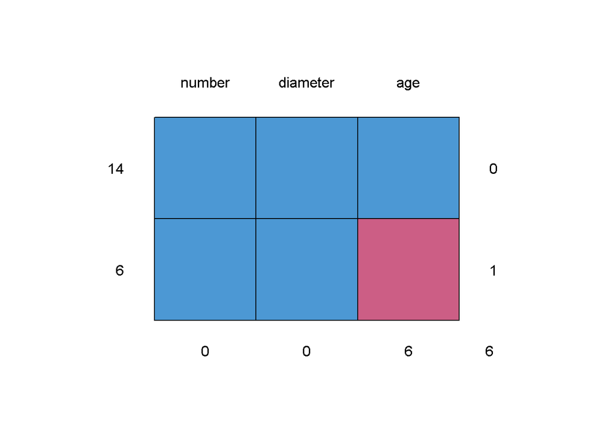

```
##    number diameter age
## 14      1        1   1 0
## 6       1        1   0 1
##         0        0   6 6
```

```r
md.pattern(trees)                        # graphical represenation of how much is missing
```

As can be seen, 6 entries are missing from the $age column of the data set, while 14 rows remain complete. In order to do any exploritory data analysis, we must look at the completed cases.

```
##    number diameter age
## 1       1     12.0 125
## 4       4      9.0  85
## 5       5     10.5  99
## 7       7      7.3  69
## 8       8     10.2 133
## 9       9     11.7 154
## 10     10     11.3 168
## 11     11      5.7  61
## 14     14     12.0 147
## 15     15      9.2 122
## 16     16      8.5 106
## 17     17      7.0  82
## 18     18     10.7  88
## 19     19      9.3  97
```

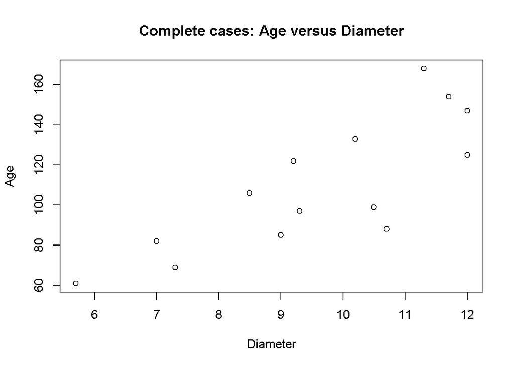

In looking at the completed cases we can see that there is some relationship between age of a tree and diameter of the tree. This is useful for when we begin to implement methods to fill in missing data as we will have something to gauge our results on.

```r
# utilize the MICE function to create 50 models for filling the Missing Data
treesMI50 <- mice(trees, m=50, defaultMethod = c("norm"))
```

[figure not shown]

```r
# Create two models from the 50 to diagnose the Missing Data Models
d1 <- mice::complete(treesMI50, 1)
d2 <- mice::complete(treesMI50, 35)

# plot replicated date from MICE over observed/completed data
stripplot(treesMI50, col = c("grey",mdc(5)),pch = c(1,20))
```

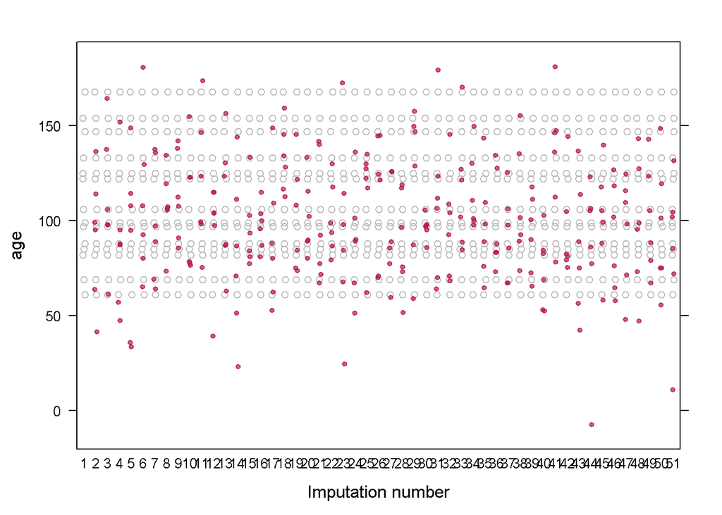

```r
stripplot(treesMI50, age~.imp, col=c("grey",mdc(2)),pch=c(1,20))
```

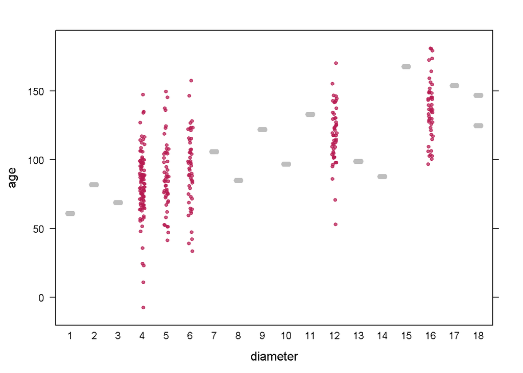

```r
stripplot(treesMI50, age~diameter, col=c("grey",mdc(2)),pch=c(1,20))
```

Utilizing the mice function, we are able to build 50 models with input values for the missing values. The easiest way to interpret what is being done is to look at a strip plot with the replicated data points layered over the completed datapoints.

```r
# create one large data set using two iterations from the initial data
treesppcheck <- rbind(trees, trees)

# ensure that the second set has all Age data terned to NA's
treesppcheck[21:40, 3] = NA

# use MICE function to fill in missing data with 50 seperate models
trees2MI5ppcheck = mice(treesppcheck, m=50, defaultMethod = c("norm"))
# use two of th models for diagnosis
d1ppcheck = mice::complete(trees2MI5ppcheck, 1)
d2ppcheck = mice::complete(trees2MI5ppcheck, 35)
```

After looking at the plots, we used a posterior predictive check to ensure I was on the right track. I used the first and thirty-fifth model to ensure more than one model was within the realm of possibility. At first glance nothing seem out of the ordinary, but comparing the completed data (the first 20 values) against the replicated data (the last 20 values) will be clearer through graphical represenation

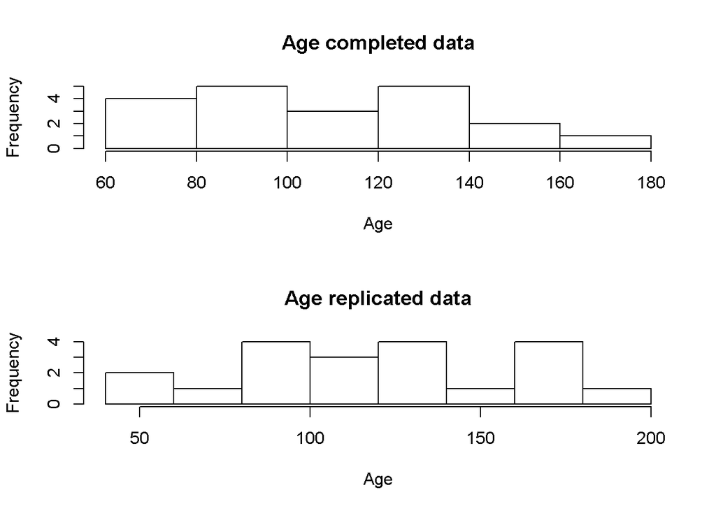

```r
par(mfcol=c(2,1))
# Histogram comparing top and bottom of the data set for completed vs replicated data for Age
hist(d1ppcheck$age[1:20], xlab = "Age", main = "Age completed data")
hist(d1ppcheck$age[21:40], xlab = "Age", main = "Age replicated data")
```

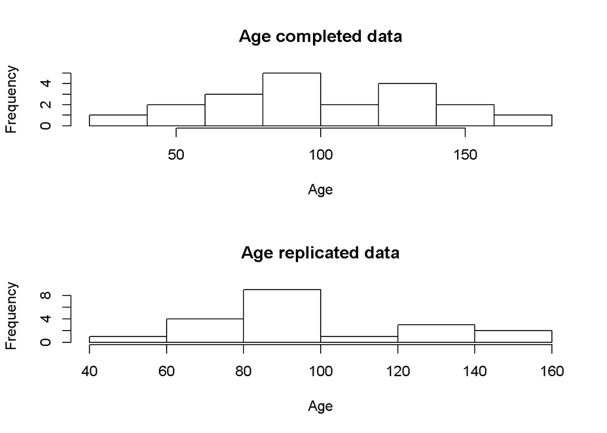

```r
# Histogram comparing top and bottom of the data set for completed vs replicated data for Age
hist(d2ppcheck$age[1:20], xlab = "Age", main = "Age completed data")
hist(d2ppcheck$age[21:40], xlab = "Age", main = "Age replicated data")
```

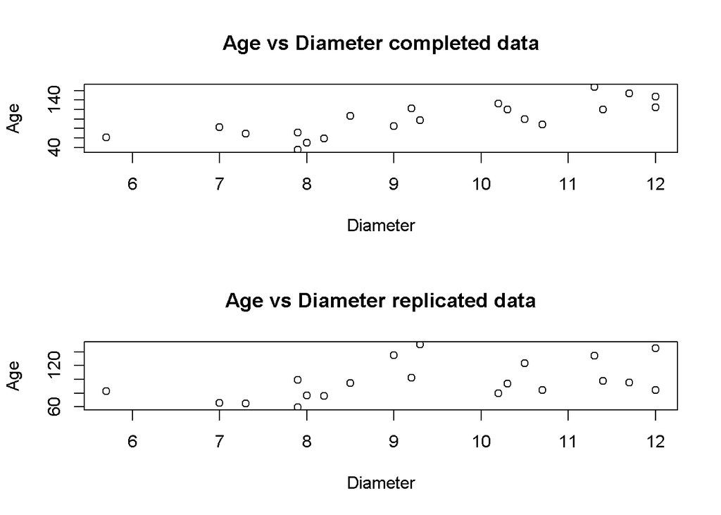

```r
# Plot to compare replicated data and completed data agaisnt diameter
plot(d2ppcheck$age[1:20]~d2ppcheck$diameter[1:20], ylab = "Age", xlab = "Diameter", main = "Age vs Diameter completed data")
plot(d2ppcheck$age[21:40]~d2ppcheck$diameter[21:40], ylab = "Age", xlab = "Diameter", main = "Age vs Diameter replicated data")
```

```r
# Create a linear regression using all of the 50 models for completeing the missing data
treereg = with(data=treesMI50, lm(age~diameter))
treereg2 = pool(treereg)
summary(treereg2, conf.int = T)
```

```
##              estimate std.error  statistic       df      p.value
## (Intercept) -21.27289 28.778517 -0.7391935 12.28396 0.4727087812
## diameter     13.62538  2.905116  4.6901334 13.22251 0.0004041078
##                  2.5 %   97.5 %
## (Intercept) -83.815513 41.26973
## diameter      7.359978 19.89078
```

### Question #2 pertains to the Nhanes data

```r
nhanes <- read.csv("file:///C:/Users/Joseph/Documents/R/IDS 702/nhanes.csv")
nhanes[nhanes=="."] = NA
nhanes_num = nhanes[,c("bmxbmi","age", "ridageyr","riagendr","ridreth2","dmdeduc","indfminc")]
nhanes_num[, ] <- sapply(nhanes_num[,], as.numeric)
```

Because the data is factored already when being read in, we must change “.” to NAs and certain columns back to numerics in order to do any kind of exploritory data analysis.

```r
# look at a summary of data
summary(nhanes_num)
```

```
##      bmxbmi          age            ridageyr        riagendr
##  Min.   :   2   Min.   :   2.0   Min.   : 0.00   Min.   :1.000
##  1st Qu.: 605   1st Qu.: 104.0   1st Qu.:10.00   1st Qu.:1.000
##  Median :1059   Median : 291.0   Median :19.00   Median :2.000
##  Mean   :1106   Mean   : 377.6   Mean   :30.06   Mean   :1.509
##  3rd Qu.:1543   3rd Qu.: 635.0   3rd Qu.:49.00   3rd Qu.:2.000
##  Max.   :2622   Max.   :1021.0   Max.   :85.00   Max.   :2.000
##  NA's   :1435   NA's   :693
##     ridreth2        dmdeduc        indfminc
##  Min.   :1.000   Min.   :2.00   Min.   : 2.000
##  1st Qu.:1.000   1st Qu.:2.00   1st Qu.: 4.000
##  Median :2.000   Median :2.00   Median : 9.000
##  Mean   :2.003   Mean   :2.76   Mean   : 8.586
##  3rd Qu.:3.000   3rd Qu.:4.00   3rd Qu.:11.000
##  Max.   :5.000   Max.   :6.00   Max.   :16.000
##                  NA's   :1744   NA's   :158
```

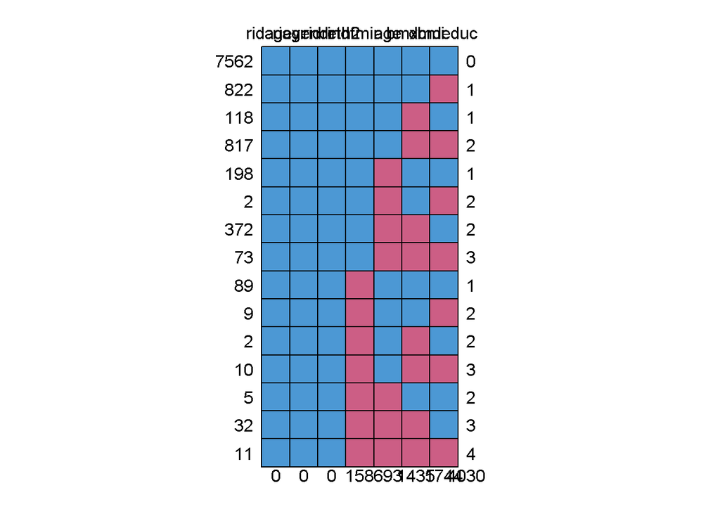

```
##      ridageyr riagendr ridreth2 indfminc age bmxbmi dmdeduc
## 7562        1        1        1        1   1      1       1    0
## 822         1        1        1        1   1      1       0    1
## 118         1        1        1        1   1      0       1    1
## 817         1        1        1        1   1      0       0    2
## 198         1        1        1        1   0      1       1    1
## 2           1        1        1        1   0      1       0    2
## 372         1        1        1        1   0      0       1    2
## 73          1        1        1        1   0      0       0    3
## 89          1        1        1        0   1      1       1    1
## 9           1        1        1        0   1      1       0    2
## 2           1        1        1        0   1      0       1    2
## 10          1        1        1        0   1      0       0    3
## 5           1        1        1        0   0      1       1    2
## 32          1        1        1        0   0      0       1    3
## 11          1        1        1        0   0      0       0    4
##             0        0        0      158 693   1435    1744 4030
```

```r
#graphically represent missing data
md.pattern(nhanes_num)
```

We can observe a number of data points throughout BMI, Age, Education, and Income missing. However since Education and Income are both factors we can change those factors that cover NAs to NA for implementation through the MICE function.

```r
# convert NA Factors to NA values
nhanes_num$indfminc[nhanes_num$indfminc >= 14] <- NA
nhanes_num$dmdeduc[nhanes_num$dmdeduc >= 7]    <- NA

summary(nhanes_num)
```

```
##      bmxbmi          age            ridageyr        riagendr
##  Min.   :   2   Min.   :   2.0   Min.   : 0.00   Min.   :1.000
##  1st Qu.: 605   1st Qu.: 104.0   1st Qu.:10.00   1st Qu.:1.000
##  Median :1059   Median : 291.0   Median :19.00   Median :2.000
##  Mean   :1106   Mean   : 377.6   Mean   :30.06   Mean   :1.509
##  3rd Qu.:1543   3rd Qu.: 635.0   3rd Qu.:49.00   3rd Qu.:2.000
##  Max.   :2622   Max.   :1021.0   Max.   :85.00   Max.   :2.000
##  NA's   :1435   NA's   :693
##     ridreth2        dmdeduc        indfminc
##  Min.   :1.000   Min.   :2.00   Min.   : 2.000
##  1st Qu.:1.000   1st Qu.:2.00   1st Qu.: 4.000
##  Median :2.000   Median :2.00   Median : 8.000
##  Mean   :2.003   Mean   :2.76   Mean   : 7.697
##  3rd Qu.:3.000   3rd Qu.:4.00   3rd Qu.:11.000
##  Max.   :5.000   Max.   :6.00   Max.   :13.000
##                  NA's   :1744   NA's   :1462
```

Now that the data is correct we can begin comparting the completed data to see if their are trends between BMI with Gender and Age as posed in the questions.

```r
# Adjust the data so only completed cases are shown/used
ccnhanes <- cc(nhanes_num)
ccnhanes
```

[output not shown]

[output cut: 6499 more lines]

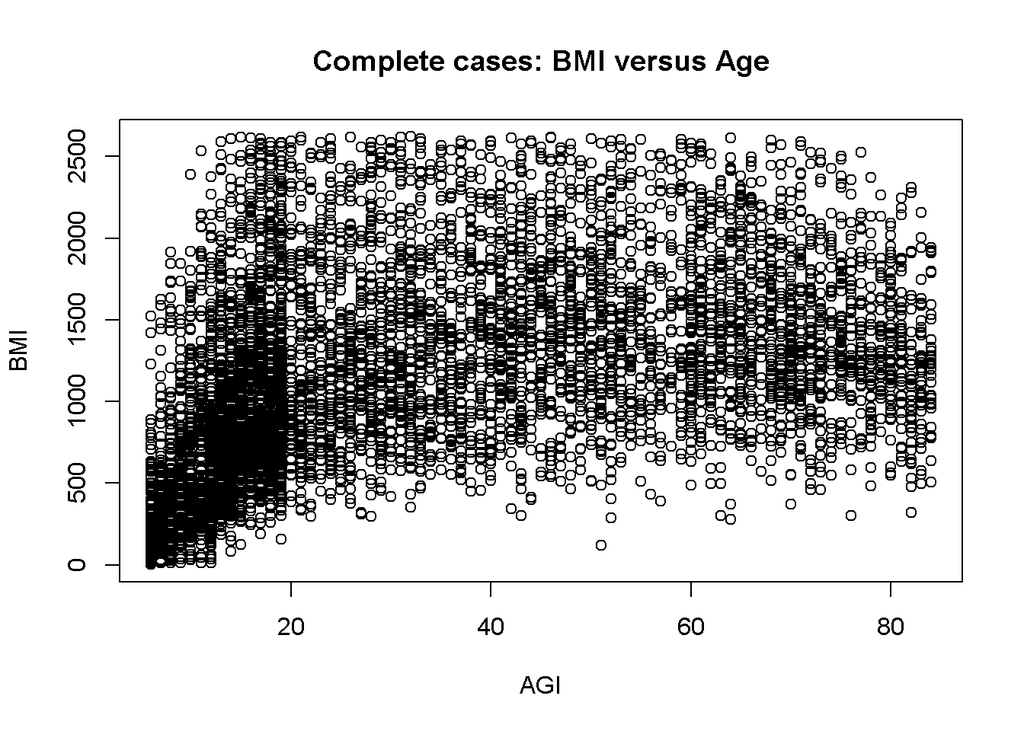

```r
# plot Completed Cases for BMI vs. Years
plot(ccnhanes$bmxbmi ~ ccnhanes$ridageyr,
     xlab = "AGI",
     ylab = "BMI",
     main = "Complete cases: BMI versus Age")
```

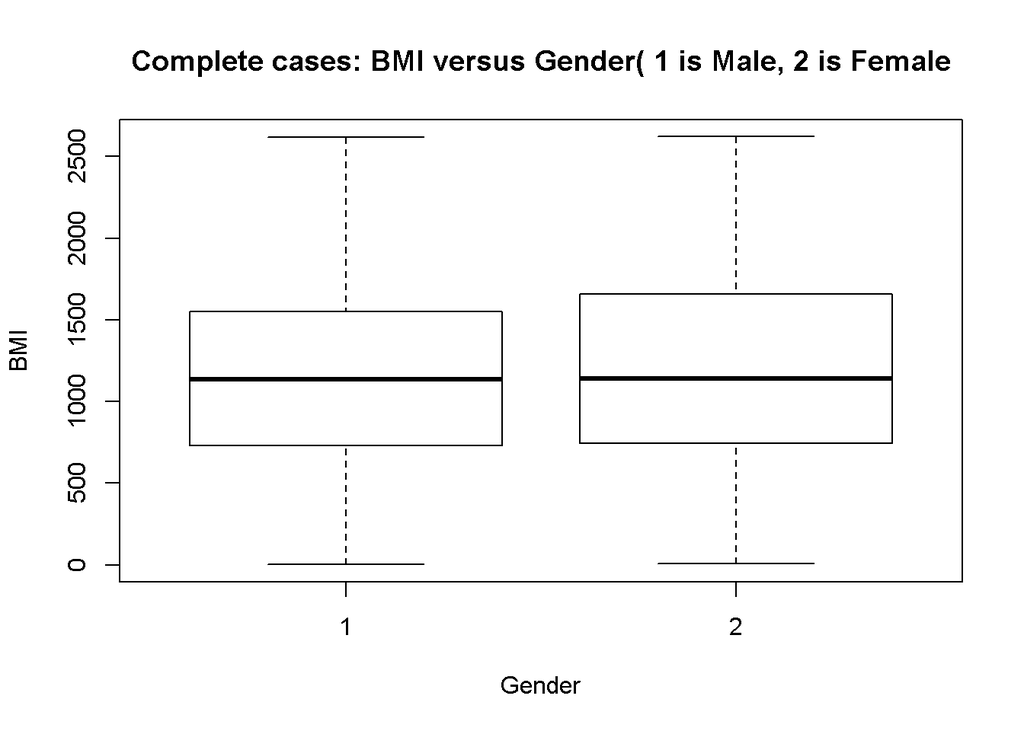

```r
# plot Complted Cases for BMI vs. Gender
boxplot(ccnhanes$bmxbmi~ccnhanes$riagendr,
     xlab = "Gender",
     ylab = "BMI",
     main = "Complete cases: BMI versus Gender( 1 is Male, 2 is Female")
```

From the initial analysis of the completed cases we can observe that generally, there is a logistic relationship between BMI and Age, however there is a large amount of fanning from the initial point, so age alone may not be the largest contributing factor to BMI, and requires additional exploration.

For gender, although there is a slightly larger variance within the firth through third quartile for womens BMI in contrast with males, it is rather minisquial, and the overall mean appears relatively similar.

```r
# Use MICE function to fill in missing data through 10 models
BMIMI50 <- mice(nhanes_num, m = 10, defaultMethod = c("norm"))
```

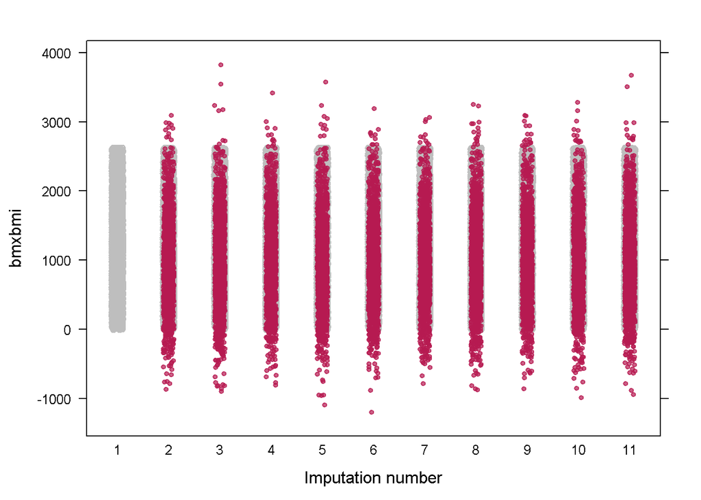

```r
# plot each of the variables that required Missing data filled.
stripplot(BMIMI50, bmxbmi~.imp, col=c("grey",mdc(2)),pch=c(1,20))
```

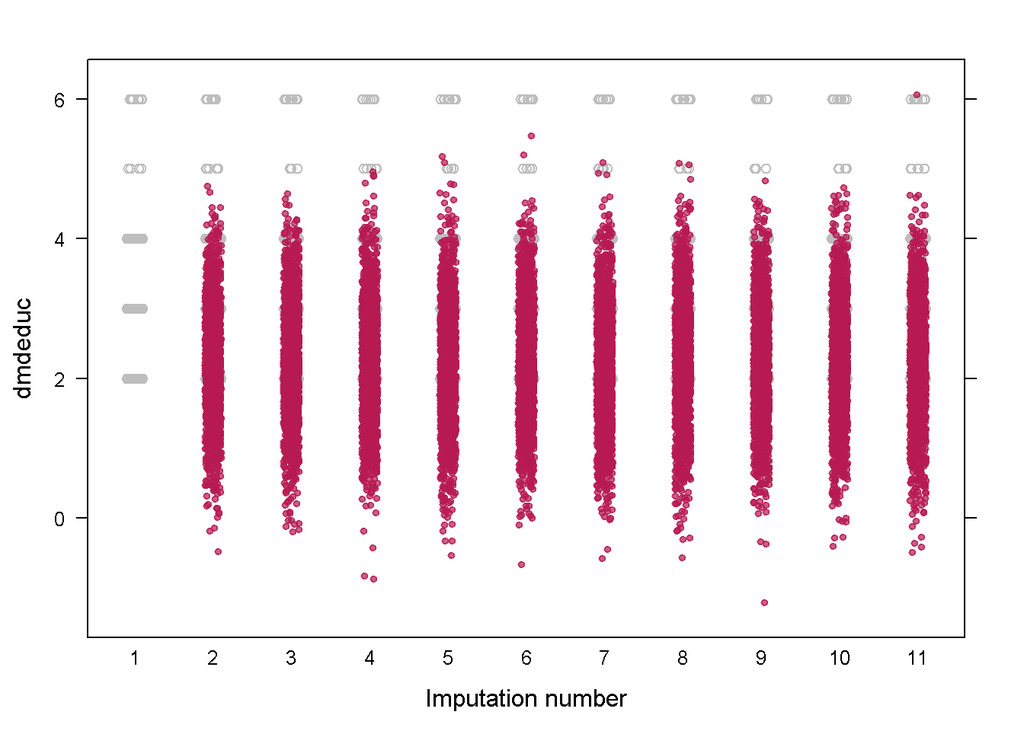

```r
stripplot(BMIMI50, dmdeduc~.imp, col=c("grey",mdc(2)),pch=c(1,20))
```

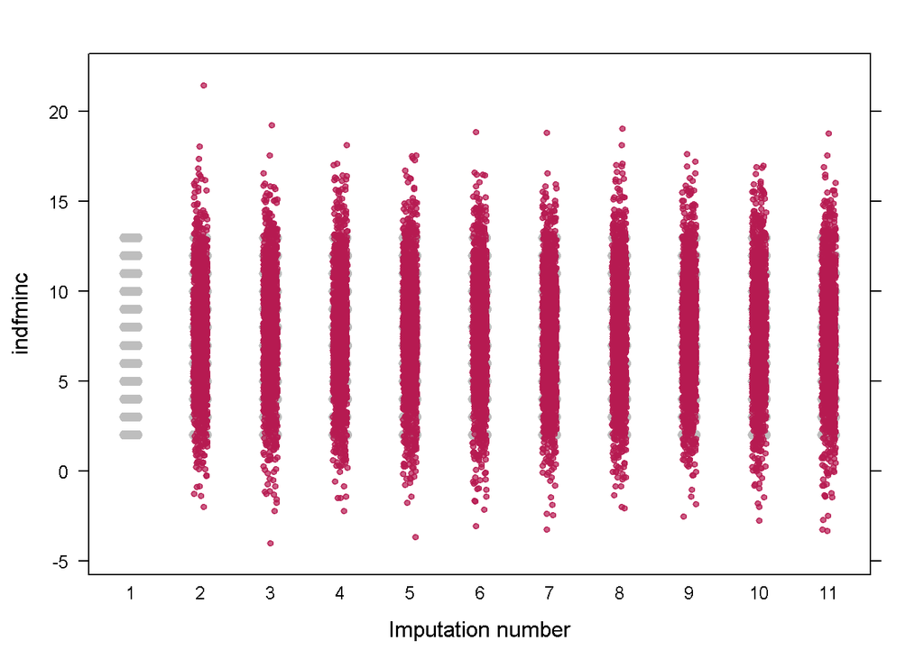

```r
stripplot(BMIMI50, indfminc~.imp, col=c("grey",mdc(2)),pch=c(1,20))
```

From the above plots we can see that replicated data for BMI, Education, and Income cover the completed data. Meaning that the MICE function filled in replicated data within an acceptable range when compared to the completed data available.

```r
# create one large data set using two iterations from the initial data
bmippcheck <- rbind(nhanes_num, nhanes_num)

# ensure that the second set has all BMI data terned to NA's
bmippcheck[10123:20244, 1] = NA

# Use MICE function to fill in missing data through 10 models
BMIMI5ppcheck = mice(bmippcheck, m = 10, defaultMethod = c("norm"))

# testing two models from the ten created in the MICE package
d1ppcheck = mice::complete(BMIMI5ppcheck, 1)
d2ppcheck = mice::complete(BMIMI5ppcheck, 5)
```

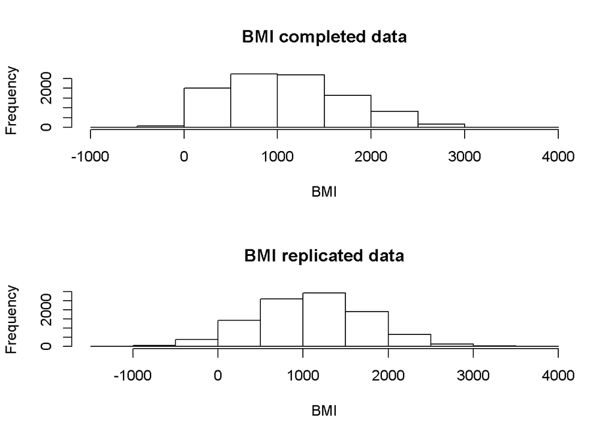

```r
# Histogram comparing top and bottom of the data set for completed vs replicated data for BMI
par(mfcol=c(2,1))
hist(d1ppcheck$bmxbmi[1:10122], xlab = "BMI", main = "BMI completed data")
hist(d1ppcheck$bmxbmi[10123:20244], xlab = "BMI", main = "BMI replicated data")
```

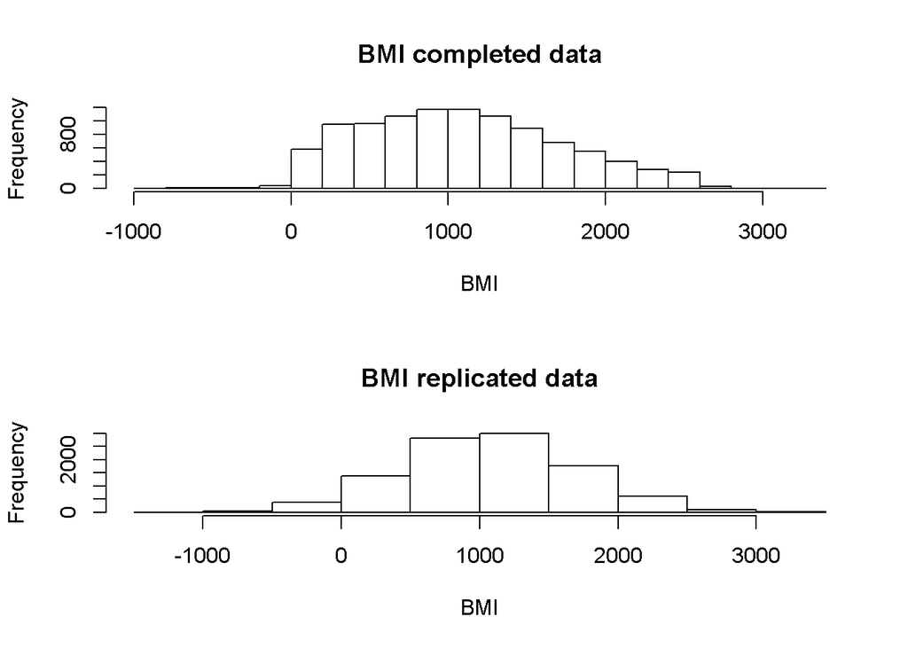

```r
# Histogram comparing top and bottom of the data set for completed vs replicated data for BMI
hist(d2ppcheck$bmxbmi[1:10122], xlab = "BMI", main = "BMI completed data")
hist(d2ppcheck$bmxbmi[10123:20244], xlab = "BMI", main = "BMI replicated data")
```

Utlizing the repicated data from before, we can see that the replicated data is closely aligned with the obseerved/completed data. This tells me that the MICE implementation is adequate for use.

```r
# Linear Regression Model using MICE data
BMIreg = with(data=BMIMI50, lm(bmxbmi~ridageyr +    # Age
                                 riagendr +         # Gender
                                 ridreth2 +         # Race
                                 dmdeduc +          # education
                                 indfminc))         # income

# Regession using a pool of all MICE models as one.
BMIreg2 = pool(BMIreg)

# Summary of Linear Regession Model
summary(BMIreg2, conf.int = T)
```

```
##               estimate std.error  statistic       df      p.value
## (Intercept) 368.114009 35.045900 10.5037682 154.6018 0.000000e+00
## ridageyr     11.025260  0.269932 40.8445780 152.0128 0.000000e+00
## riagendr     46.254093 11.353430  4.0740194 840.8432 5.058148e-05
## ridreth2     22.349754  6.203023  3.6030425 140.2346 3.329880e-04
## dmdeduc     101.262068  7.780656 13.0145921 140.4406 0.000000e+00
## indfminc      0.443426  2.017318  0.2198097 102.2125 8.260727e-01
##                  2.5 %     97.5 %
## (Intercept) 298.883386 437.344631
## ridageyr     10.491957  11.558562
## riagendr     23.969703  68.538482
## ridreth2     10.086224  34.613284
## dmdeduc      85.879713 116.644423
## indfminc     -3.557815   4.444667
```